# JSC370_Assignment3

Elaine Dai

2024-03-20

# APIs (Part 1)

The aim is to get more practice working with APIs. We will use and API maintained by NASA for retrieving information about near earth objects (NEOs), asteroids that pass close to Earth. The documentation is available at https://api.nasa.gov/ (scroll down to the API titled Asteroids NeoWs). First you will need an API key for accessing the service. You can get one at https://api.nasa.gov/ where you will need to supply an email address, which can be either your UofT email or a personal email address.

```r
library(httr)
library(kableExtra)
library(ggplot2)
library(tidyverse)
library(dplyr)
library(webshot2)
```

## 1

Use start_date and end_date along with the API key to submit an HTTP GET request to the NASA NeoWs Feed API. Pick a range of a few days.

```r
response <- GET(
  url   = "https://api.nasa.gov/neo/rest/v1/feed?",
  query = list(start_date = "2024-03-01",
               end_date = "2024-03-08",
               api_key = "nC63KBeJdJyBBdFJF09bJ0CrUMERWeRR8szcai3G")
)
```

```r
neo <- httr::content(response)
```

## 2

There should be 3 elements in your retrieved query: a list of urls, the number of near earth objects that had their nearest approach during the time spanned by start_date and end_date, and an object whose attributes are the dates (represented by strings of the form YYYY-MM-DD) in the time spanned by start_date and end_date. Each such date attribute has an array of values, each of which represents a near Earth object. Summarize how many near earth objects you retrieved and some of the parameters that are available for them.

```r
neo$element_count
```

```
## [1] 145
```

I retrived 145 NEOs, and some available parameters are id, name, absolute magnitude, estimated diameter, is_potentially_hazardous_asteroid, close approach data, and is_sentry_object.

## 3

Extract information on estimated_diameter, is_potentially_hazardous_asteroid, and relative_velocity, and create a table with this information for all of the NEOs pulled in your date range.

```r
neos <- data.frame(
  date = character(),
  name = character(),
  estimated_diameter_min_km = numeric(),
  estimated_diameter_max_km = numeric(),
  is_potentially_hazardous_asteroid = logical(),
  relative_velocity_kmph = numeric(),
  stringsAsFactors = FALSE
)
```

```r
# Loop through each date in the near_earth_objects
for (date in names(neo$near_earth_objects)) {
  for (neo_object in neo$near_earth_objects[[date]]) {
    date <- date
    name <- neo_object$name
    ed_min_km <- neo_object$estimated_diameter$kilometers$estimated_diameter_min
    ed_max_km <- neo_object$estimated_diameter$kilometers$estimated_diameter_max
    is_potentially_ha <- neo_object$is_potentially_hazardous_asteroid
    relative_velocity_kmps <- as.numeric(neo_object$close_approach_data[[1]]$relative_velocity$kilometers_per_second)

    # Combine the extracted information into a single row
    neo_row <- data.frame(
      date,
      name,
      ed_min_km,
      ed_max_km,
      is_potentially_ha,
      relative_velocity_kmps,
      stringsAsFactors = FALSE
    )

    neos <- rbind(neos, neo_row)
  }
}
```

```r
kable_output <- kable(neos, "html")
kable_output <- kable_styling(kable_output, "striped", full_width = F)
kable_output <- scroll_box(kable_output, width = "100%", height = "500px")
kable_output
```

| date | name | ed_min_km | ed_max_km | is_potentially_ha | relative_velocity_kmps |
| --- | --- | --- | --- | --- | --- |
| 2024-03-05 | 490636 (2010 DP) | 0.5158875 | 1.1535594 | FALSE | 18.045904 |
| 2024-03-05 | (2005 CE41) | 0.0461907 | 0.1032856 | FALSE | 23.075482 |
| 2024-03-05 | (2015 XQ378) | 0.0406027 | 0.0907904 | FALSE | 9.108366 |
| 2024-03-05 | (2016 WD7) | 0.0092163 | 0.0206082 | FALSE | 2.498919 |
| 2024-03-05 | (2021 UF1) | 0.0258556 | 0.0578149 | FALSE | 9.934602 |
| 2024-03-05 | (2021 VP6) | 0.1283970 | 0.2871045 | FALSE | 18.269076 |
| 2024-03-05 | (2023 UU6) | 0.0111315 | 0.0248909 | FALSE | 10.870378 |
| 2024-03-05 | (2024 EM3) | 0.0140525 | 0.0314224 | FALSE | 8.968422 |
| 2024-03-05 | (2024 EW3) | 0.0056177 | 0.0125615 | FALSE | 3.374305 |
| 2024-03-06 | 533671 (2014 LJ21) | 1.6389095 | 3.6647131 | TRUE | 28.618037 |
| 2024-03-06 | (2012 WB25) | 0.4310771 | 0.9639178 | FALSE | 14.236631 |
| 2024-03-06 | (2015 RO36) | 0.0689533 | 0.1541842 | FALSE | 14.972386 |
| 2024-03-06 | (2016 QA84) | 0.0860112 | 0.1923269 | FALSE | 18.637844 |
| 2024-03-06 | (2020 AT) | 0.0242412 | 0.0542051 | FALSE | 7.525061 |
| 2024-03-06 | (2020 FO3) | 0.0637610 | 0.1425739 | FALSE | 13.072628 |
| 2024-03-06 | (2021 OH) | 0.0118728 | 0.0265485 | FALSE | 14.906057 |
| 2024-03-06 | (2021 VC) | 0.0130784 | 0.0292442 | FALSE | 16.490760 |
| 2024-03-06 | (2022 BC1) | 0.0497227 | 0.1111834 | FALSE | 3.761525 |
| 2024-03-06 | (2022 DA1) | 0.0157963 | 0.0353216 | FALSE | 18.147537 |
| 2024-03-06 | (2022 EA5) | 0.0144064 | 0.0322137 | FALSE | 13.323003 |
| 2024-03-06 | (2023 HU5) | 0.0081013 | 0.0181151 | FALSE | 4.813032 |
| 2024-03-06 | (2024 EC1) | 0.0571683 | 0.1278321 | FALSE | 19.117916 |
| 2024-03-06 | (2024 ER1) | 0.0587428 | 0.1313530 | FALSE | 7.937107 |
| 2024-03-06 | (2024 FH) | 0.0481011 | 0.1075573 | FALSE | 19.925615 |
| 2024-03-03 | 85182 (1991 AQ) | 0.9966782 | 2.2286403 | TRUE | 17.126772 |
| 2024-03-03 | (2008 CL1) | 0.3377186 | 0.7551617 | FALSE | 15.172410 |
| 2024-03-03 | (2008 EA8) | 0.0904805 | 0.2023205 | FALSE | 15.339231 |
| 2024-03-03 | (2015 VR1) | 0.1764229 | 0.3944936 | FALSE | 16.808959 |
| 2024-03-03 | (2019 DA1) | 0.0170826 | 0.0381979 | FALSE | 13.384998 |
| 2024-03-03 | (2019 UX1) | 0.0400456 | 0.0895447 | FALSE | 17.493449 |

[output cut: 115 more lines]

## 4

Explore how the number of near Earth objects per day changes from day to day. Is this number correlated from one day to the next?

```r
daily_counts <- sapply(neo$near_earth_objects, length)
daily_counts <- data.frame(Date = as.Date(names(daily_counts)), Count = daily_counts, row.names = NULL)
daily_counts
```

```
##         Date Count
## 1 2024-03-05     9
## 2 2024-03-06    15
## 3 2024-03-03    18
## 4 2024-03-04    30
## 5 2024-03-07    14
## 6 2024-03-08    19
## 7 2024-03-01    23
## 8 2024-03-02    17
```

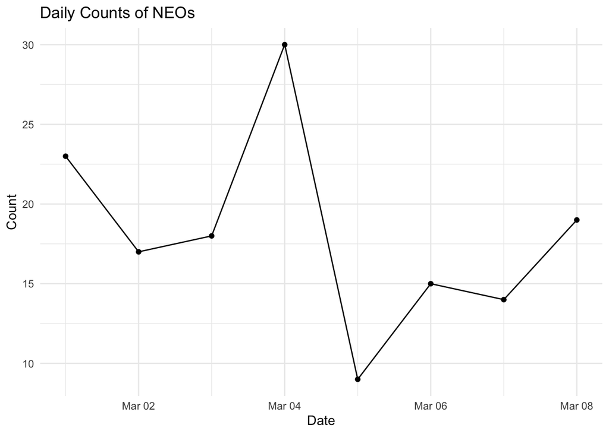

```r
daily_counts |>
  ggplot(aes(x = Date, y = Count)) +
  geom_line() +
  geom_point() +
  theme_minimal() +
  labs(title = "Daily Counts of NEOs",
       x = "Date",
       y = "Count")
```

```r
cor.test(daily_counts$Count[-7], daily_counts$Count[-1])
```

```
##
##  Pearson's product-moment correlation
##
## data:  daily_counts$Count[-7] and daily_counts$Count[-1]
## t = -0.13973, df = 5, p-value = 0.8943
## alternative hypothesis: true correlation is not equal to 0
## 95 percent confidence interval:
##  -0.7788466  0.7247278
## sample estimates:
##         cor
## -0.06236899
```

# 5

Explore associations between the three variables extracted in 3.

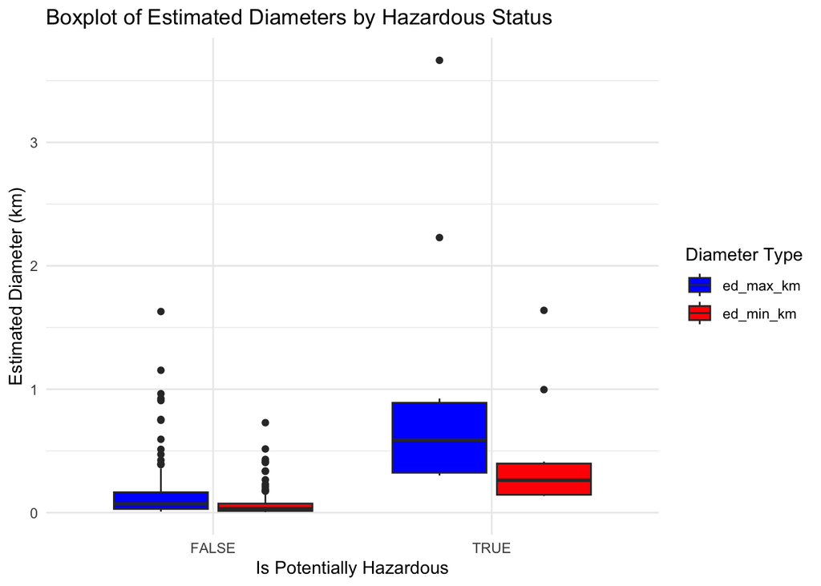

```r
neos_longer <- neos |>
  pivot_longer(cols = starts_with("ed"),
               names_to = "Diameter_Type",
               values_to = "Diameter_km")

neos_longer |>
  ggplot(aes(x = is_potentially_ha, y = Diameter_km, fill = Diameter_Type)) +
  geom_boxplot() +
  scale_fill_manual(values = c("blue", "red")) +
  labs(title = "Boxplot of Estimated Diameters by Hazardous Status",
       x = "Is Potentially Hazardous",
       y = "Estimated Diameter (km)",
       fill = "Diameter Type") +
  theme_minimal()
```

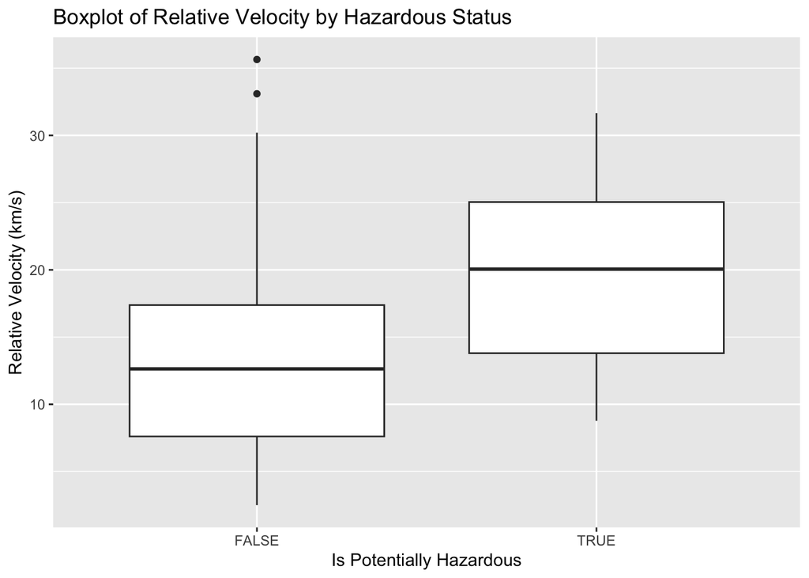

```r
# Boxplot for Relative Velocity vs Hazardous Status
neos |>
  ggplot(aes(x = is_potentially_ha, y = relative_velocity_kmps)) +
  geom_boxplot() +
  labs(title = "Boxplot of Relative Velocity by Hazardous Status",
       x = "Is Potentially Hazardous",
       y = "Relative Velocity (km/s)")
```

[figure not shown]

```r
neos_longer |>
  ggplot(aes(x = relative_velocity_kmps,
             y = Diameter_km,
             group = Diameter_Type,
             color = Diameter_Type)) +
  geom_line() +
  scale_color_manual(values = c("blue", "red")) +
  labs(title = "Estimated Diameter vs. Relative Velocity",
       x = "Relative Velocity (km/h)",
       y = "Estimated Diameter (km)",
       color = "Diameter Type") +
  theme_minimal()
```

```r
# Correlation between Estimated Diameter and Relative Velocity
cor.test(neos$ed_min_km, neos$relative_velocity_kmps)
```

```
##
##  Pearson's product-moment correlation
##
## data:  neos$ed_min_km and neos$relative_velocity_kmps
## t = 4.6026, df = 143, p-value = 9.124e-06
## alternative hypothesis: true correlation is not equal to 0
## 95 percent confidence interval:
##  0.2083964 0.4933265
## sample estimates:
##       cor
## 0.3592033
```

```r
cor.test(neos$ed_max_km, neos$relative_velocity_kmps)
```

```
##
##  Pearson's product-moment correlation
##
## data:  neos$ed_max_km and neos$relative_velocity_kmps
## t = 4.6026, df = 143, p-value = 9.124e-06
## alternative hypothesis: true correlation is not equal to 0
## 95 percent confidence interval:
##  0.2083964 0.4933265
## sample estimates:
##       cor
## 0.3592033
```

The box plots suggest that potentially hazardous objects tend to have larger estimated diameters compared to non-hazardous objects, and the median relative velocity appears to be higher for the potentially hazardous objects.

Both minimum and maximum estimated diameters appear to have some form of relationship with relative velocity, indicated by the trend in the lines, although this relationship does not appear to be very strong.

The correlation test between estimated diameter and relative velocity has resulted in a Pearson correlation coefficient of 0.359, with a p-value < 0.001. This suggests that there is a positive but moderate correlation between the estimated diameter and relative velocity.

# Text Mining (Part 2)

The Consumer Financial Protection Bureau maintains a database of customer complaints. We will use text mining to see if there are any trends in the reported consumer’s narrative description of the issue/complaint. The data can be acquired here: https://www.consumerfinance.gov/data-research/consumer-complaints/.

```r
library(tidytext)
library(tm)
```

## 1

Using data.table (the file is very large), subset the data to include only the last 2 years (use Date received). Summarize the dataset dimensions and variables. Bonus points if you use the API to acquire the data!

I am using the data in last year only.

```r
response2 <- GET(
  url   = "https://www.consumerfinance.gov/data-research/consumer-complaints/search/api/v1/?",
  query = list(date_received_min = "2023-03-21",
               date_received_max = "2024-03-21",
               format = "csv",
               has_narrative = "true",
               no_aggs = "true")
)
```

```r
content_data <- httr::content(response2, "text", encoding = "UTF-8")
```

```r
complaints <- read.csv(textConnection(content_data), stringsAsFactors = FALSE)
```

```r
dim(complaints)
```

```
## [1] 434295     18
```

```r
names(complaints)
```

```
##  [1] "Date.received"                "Product"
##  [3] "Sub.product"                  "Issue"
##  [5] "Sub.issue"                    "Consumer.complaint.narrative"
##  [7] "Company.public.response"      "Company"
##  [9] "State"                        "ZIP.code"
## [11] "Tags"                         "Consumer.consent.provided."
## [13] "Submitted.via"                "Date.sent.to.company"
## [15] "Company.response.to.consumer" "Timely.response."
## [17] "Consumer.disputed."           "Complaint.ID"
```

## 2

Tokenize the complaints (consumer complaint narrative) and count the number of each token. Do you see anything interesting? Does removing stop words change what tokens appear as the most frequent? What are the 5 most common tokens for the complaints after removing stopwords?

```r
tokens <- complaints |>
  select(Narrative = Consumer.complaint.narrative, Issue) |>
  unnest_tokens(word, Narrative)
```

```r
tokens |>
  count(word, sort = TRUE) |>
  slice_max(order_by = n, n = 10)
```

```
##    word       n
## 1  xxxx 7628385
## 2   the 2954880
## 3    to 2343607
## 4     i 1975795
## 5   and 1777233
## 6     a 1646603
## 7    my 1575633
## 8    of 1573479
## 9  that  971508
## 10   xx  879462
```

The most frequent tokens are all stop words or words that makes no sense.

```r
tokens_no_sw <- tokens |>
  filter(!word %in% stopwords("english"),
         !str_detect(word, "^x+$"),
         !grepl("[[:digit:]]+", word))

tokens_no_sw |>
  count(word, sort = TRUE) |>
  slice_max(order_by = n, n = 10)
```

```
##           word      n
## 1       credit 849621
## 2      account 648909
## 3  information 619085
## 4     consumer 585651
## 5       report 569393
## 6    reporting 474580
## 7      section 262224
## 8     accounts 234226
## 9       agency 194832
## 10       u.s.c 173397
```

Removing the stop words changes the most frequent tokens. The 5 most common tokens for the complaints after removing stopwords and words containing only “x” or numeric values are: credit, account, information, consumer and report.

## 3

Tokenize the complaints into bigrams. Find the 10 most common bigrams and visualize them with ggplot2.

```r
tokens_bigram_count <- complaints |>
  select(Narrative = Consumer.complaint.narrative, Issue) |>
  unnest_tokens(ngram, Narrative, token = "ngrams", n = 2) |>
  count(ngram, sort = TRUE)
```

```r
tokens_bigram_count |> slice_max(order_by = n, n = 10)
```

```
##            ngram       n
## 1      xxxx xxxx 5630914
## 2          xx xx  435166
## 3      my credit  371762
## 4         i have  350252
## 5         of the  325730
## 6        xx xxxx  318236
## 7  credit report  276841
## 8          on my  234744
## 9           i am  222491
## 10        to the  175161
```

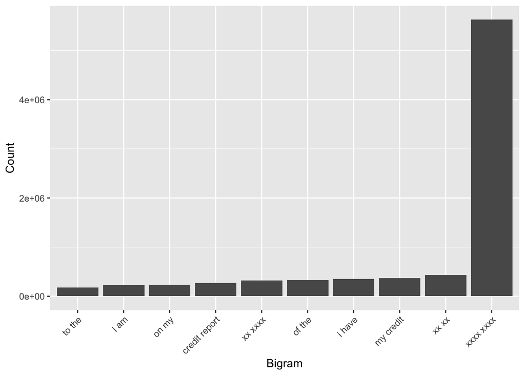

```r
tokens_bigram_count |>
  slice_max(order_by = n, n = 10) |>
  ggplot(aes(reorder(ngram, n), y = n)) +
  labs(y = "Count", x = "Bigram") +
  geom_bar(stat = "identity") +
  theme(axis.text.x = element_text(angle = 45, hjust = 1))
```

After filtering out all the bigrams that contains stop words or words only with “x”, the new words with top 10 frequencies are:

```r
sw_start <- paste0("^", paste(stopwords("english"), collapse=" |^"), "$")
sw_end <- paste0("", paste(stopwords("english"), collapse="$| "), "$")
```

```r
# Filter out bigrams containing any stop word or strings with only 'x'
filtered_tokens_bigram <- tokens_bigram_count |>
  filter(!grepl(sw_start, ngram, ignore.case = TRUE),
         !grepl(sw_end, ngram, ignore.case = TRUE),
         !grepl("\\bx+\\b", ngram, ignore.case = TRUE))
```

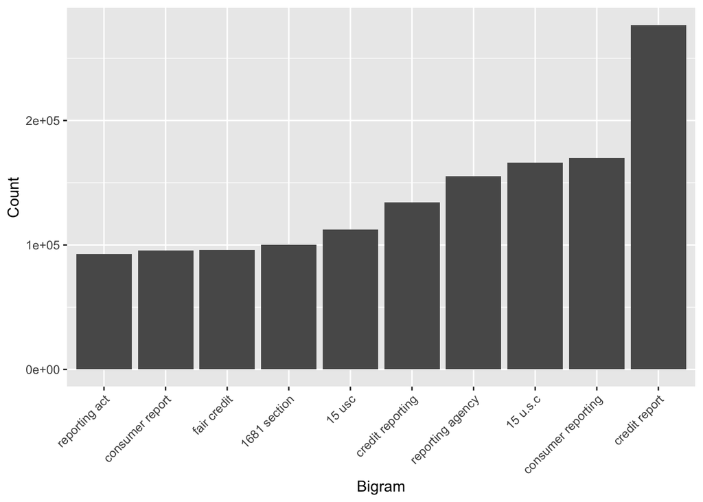

```r
filtered_tokens_bigram |>
  slice_max(order_by = n, n = 10) |>
  ggplot(aes(reorder(ngram, n), y = n)) +
  labs(y = "Count", x = "Bigram") +
  geom_bar(stat = "identity") +
  theme(axis.text.x = element_text(angle = 45, hjust = 1))
```

## 4

Calculate the TF-IDF value for the complaints in the top 3 issues. Here, the issue is like the document. What are the 5 tokens from each issue with the highest TF-IDF value? How are the results different from the answers you got in question 1?

```r
top_issues <- complaints |>
  count(Issue, sort = TRUE) |>
  top_n(3) |>
  pull(Issue)
top_issues
```

```
## [1] "Incorrect information on your report"
## [2] "Improper use of your report"
## [3] "Problem with a credit reporting company's investigation into an existing problem"
```

```r
tf_idf_values <- tokens_no_sw |>
  count(Issue, word) |>
  bind_tf_idf(word, Issue, n) |>
  arrange(desc(tf_idf))
head(tf_idf_values)
```

```
##                                        Issue        word n         tf       idf
## 1                          Property was sold  reposessed 1 0.03846154 2.5649494
## 2                          Property was sold     auction 3 0.11538462 0.8472979
## 3                          Property was sold reposession 1 0.03846154 2.2082744
## 4 Property was damaged or destroyed property        msgs 1 0.02857143 2.0259529
## 5 Property was damaged or destroyed property        blew 2 0.05714286 0.9844990
## 6                          Property was sold     onemain 1 0.03846154 0.9844990
##       tf_idf
## 1 0.09865190
## 2 0.09776514
## 3 0.08493363
## 4 0.05788437
## 5 0.05625708
## 6 0.03786535
```

```r
top_tokens_per_issue <- tf_idf_values |>
  filter(Issue %in% top_issues) |>
  group_by(Issue) |>
  top_n(5, tf_idf) |>
  ungroup() |>
  arrange(Issue, desc(tf_idf))
```

```r
top_tokens_per_issue |> select(Issue, word)
```

```
## # A tibble: 15 × 2
##    Issue                                                                   word
##    <chr>                                                                   <chr>
##  1 Improper use of your report                                             u.s.c
##  2 Improper use of your report                                             sect…
##  3 Improper use of your report                                             cons…
##  4 Improper use of your report                                             furn…
##  5 Improper use of your report                                             repo…
##  6 Incorrect information on your report                                    repo…
##  7 Incorrect information on your report                                    repo…
##  8 Incorrect information on your report                                    items
##  9 Incorrect information on your report                                    cons…
## 10 Incorrect information on your report                                    u.s.c
## 11 Problem with a credit reporting company's investigation into an existi… repo…
## 12 Problem with a credit reporting company's investigation into an existi… repo…
## 13 Problem with a credit reporting company's investigation into an existi… sect…
## 14 Problem with a credit reporting company's investigation into an existi… inac…
## 15 Problem with a credit reporting company's investigation into an existi… unve…
```